# Multivariate Linear Regression

In this homework, we will investigate multivariate linear regression using Gradient Descent and Stochastic Gradient Descent. We will also examine the relationship between the cost function, the convergence of gradient descent, overfitting problem, and the learning rate.

Download the file “dataForTraining.txt” in the attached files called “Homework 2”. This is a training dataset of apartment prices in Haizhu District, Guangzhou, Guangdong, China, where there are 50 training instances, one line per one instance, formatted in three columns separated with each other by a whitespace. The data in the first and the second columns are sizes of the apartments in square meters and the distances to the Double-Duck-Mountain Vocational Technical College in kilo-meters, respectively, while the data in the third are the corresponding prices in billion RMB. Please build a multivariate linear regression model with the training instances by script in any programming languages to predict the prices of the apartments. For evaluation purpose, please also download the file “dataForTesting.txt” (the same format as that in the file of training data) in the same folder.

```python
import numpy as np
import pandas as pd
from matplotlib import pyplot as plt
from mpl_toolkits.mplot3d import Axes3D
```

The following cell is going to processing the picture in this experiment.

```python
# read train data
dataframe1 = pd.read_csv('dataForTraining.txt', sep=' ', header=None,
                         names=['train_size', 'train_distance', 'train_price'])
train_sizes = dataframe1[['train_size']].values/10
train_distances = dataframe1[['train_distance']].values
train_prices = dataframe1[['train_price']].values

# read test data
dataframe2 = pd.read_csv('dataForTesting.txt', sep=' ', header=None, names=['test_size', 'test_distance', 'test_price'])
test_sizes = dataframe2[['test_size']].values/10
test_distances = dataframe2[['test_distance']].values
test_prices = dataframe2[['test_price']].values
```

Visualization of the linear regression, including observation scatter and regression plat contour.

```python
# show the regression
def show_regression(train_sizes, train_distances, train_prices, test_sizes, test_distances, test_prices, w1, w2, bias):

    # scatter
    fig = plt.figure()
    ax = plt.axes(projection='3d')
    plt.title('Apartment Prices Linear Regression',fontsize=12)
    ax.set_xlabel('Size/100m^2', fontsize=14)
    ax.set_ylabel('Distance/Km', fontsize=14)
    ax.set_zlabel('Price/*1000RMB', fontsize=14)
    ax.scatter3D(train_sizes*10, train_distances, train_prices, color='#0000ff')
    ax.scatter3D(test_sizes*10, test_distances, test_prices, color='#ff0000')

    # contour
    x,y = np.meshgrid(np.linspace(6.,16.,10),np.linspace(0.,12.5,10))
    predicts = w1*x+w2*y+bias*np.linspace(1.,1.,10)
    ax = plt.gca(projection='3d')
    ax.contour(x*10,y,predicts,100,colors='#bbbbbb')
    plt.show()
```

Class linear regression defines the LR method. In this class, `lr`, `w1`(w_size), `w2`(w_dist), `bias`, `n_epoch`, `k`, and `iter_num` are defined as private variables. Two methods `train_GD` and `train_SGD` train the model based on training set, while test set are used in `test` method.

```python
class LinearRegression(object):


    # class initialization
    def __init__(self, lr, w1, w2, bias, n_epochs, k):
        self.lr = lr
        self.w1 = w1
        self.w2 = w2
        self.bias = bias
        self.n_epochs = n_epochs
        self.k = k
        self.iter_num = int(self.n_epochs/self.k)



    # train the weights using GD
    def train_GD(self):
        iter_errs = np.zeros((self.iter_num,1))
        iter_losses = np.zeros((self.iter_num,1))

        for epoch in range(self.n_epochs):
            iteration = int(epoch/self.k)
            train_predicts = np.zeros((50,1))
            train_errors = np.zeros((50,1))

            train_predicts = self.w1*train_sizes+self.w2*train_distances+self.bias*np.ones((50,1))
            train_errors = train_prices-train_predicts

            self.w1 += self.lr*sum(np.multiply(train_errors, train_sizes))/50
            self.w2 += self.lr*sum(np.multiply(train_errors, train_distances))/50
            self.bias += self.lr*sum(train_errors)/50

            # evaluate the performance
            if epoch%self.k == self.k-1:
                iter_errs[iteration] = sum(abs(train_errors)/50)
                iter_losses[iteration] = sum(np.power(train_errors,2)/100)
                print("-------------------------------------------- Iteration "+str(iteration)+" --------------------------------------------\n")
                print("w_sizes, w_distances, w_bias = "+str(self.w1/10)+", "+str(self.w2)+", "+str(self.bias)+" correspondingly.\n")
                print("The average train error is "+str(iter_errs[iteration])+", the average train loss is "+str(iter_losses[iteration])+".\n")

        # plot error curve
        print("-------------------------------------------- Training Curve --------------------------------------------\n")
        plt.title('Error and Loss Curve',fontsize=12)
        plt.plot(range(self.iter_num), iter_errs, label='errors', c='b')
        plt.plot(range(self.iter_num), iter_losses, label='losses', c='g')
        plt.axis()
        plt.legend()
        plt.show()



    # train the weights using SGD
    def train_SGD(self):
        iter_errs = np.zeros((self.iter_num,1))
        iter_losses = np.zeros((self.iter_num,1))

        for epoch in range(self.n_epochs):
            iteration = int(epoch/self.k)
            train_predicts = np.zeros((50,1))
            train_errors = np.zeros((50,1))

            for i in range(50):
                train_predicts[i] = self.w1*train_sizes[i]+self.w2*train_distances[i]+self.bias
                train_errors[i] = train_prices[i]-train_predicts[i]
                self.w1 += self.lr*(train_errors[i])*train_sizes[i]
                self.w2 += self.lr*(train_errors[i])*train_distances[i]
                self.bias += self.lr*(train_errors[i])

            # evaluate the performance
            if epoch%self.k == self.k-1:
                iter_errs[iteration] = sum(abs(train_errors)/50)
                iter_losses[iteration] = sum(np.power(train_errors,2)/100)
                print("-------------------------------------------- Iteration "+str(iteration)+" --------------------------------------------\n")
                print("w_sizes, w_distances, w_bias = "+str(self.w1/10)+", "+str(self.w2)+", "+str(self.bias)+" correspondingly.\n")
                print("The average train error is "+str(iter_errs[iteration])+", the average train loss is "+str(iter_losses[iteration])+".\n")

        # plot error curve
        print("-------------------------------------------- Training Curve --------------------------------------------\n")
        plt.title('Error and Loss Curve',fontsize=12)
        plt.plot(range(self.iter_num), iter_errs, label='errors', c='b')
        plt.plot(range(self.iter_num), iter_losses, label='losses', c='g')
        plt.axis()
        plt.legend()
        plt.show()


    # test our model
    def test(self):
        test_predicts = np.zeros((10,1))
        test_errors = np.zeros((10,1))
        for i in range(10):
            test_predicts[i] = self.w1*test_sizes[i]+self.w2*test_distances[i]+self.bias
            test_errors[i] = test_prices[i]-test_predicts[i]
        print("\n-------------------------------------------- Test Results --------------------------------------------\n")
        print("The average test error is : "+str(sum(abs(test_errors))/10)+".\n")
        print("The average test loss is : "+str(sum(np.power(test_errors,2))/20)+".\n")
```

## Exercise 1

How many parameters do you use to tune this linear regression model? Please use **Gradient Descent** to obtain the optimal parameters. Before you train the model, please set the number of iterations to be 1500000, the learning rate to 0.00015, the initial values of all the parameters to 0.0. During training, at every 100000 iterations, i.e., 100000 , 200000,…, 1500000, report the current training error and the testing error in a figure (you can draw it by hands or by any software). What can you find in the plots? Please analyze the plots.

```
-------------------------------------------- Iteration 0 --------------------------------------------

w_sizes, w_distances, w_bias = [7.06203048], [-72.74101927], [49.18384041] correspondingly.

The average train error is [6.38585383], the average train loss is [28.29630539].

-------------------------------------------- Iteration 1 --------------------------------------------

w_sizes, w_distances, w_bias = [6.88957561], [-72.53405757], [66.58493721] correspondingly.

The average train error is [3.03439445], the average train loss is [6.68153744].

-------------------------------------------- Iteration 2 --------------------------------------------

w_sizes, w_distances, w_bias = [6.81622573], [-72.44603096], [73.98611054] correspondingly.

The average train error is [1.93535896], the average train loss is [2.77134185].

-------------------------------------------- Iteration 3 --------------------------------------------

w_sizes, w_distances, w_bias = [6.78502797], [-72.40859079], [77.13403663] correspondingly.

The average train error is [1.82805336], the average train loss is [2.06397226].

-------------------------------------------- Iteration 4 --------------------------------------------

w_sizes, w_distances, w_bias = [6.77175869], [-72.39266643], [78.47293767] correspondingly.

The average train error is [1.87234897], the average train loss is [1.93600635].

-------------------------------------------- Iteration 5 --------------------------------------------

w_sizes, w_distances, w_bias = [6.76611489], [-72.38589336], [79.04240974] correspondingly.

The average train error is [1.89118914], the average train loss is [1.91285682].

-------------------------------------------- Iteration 6 --------------------------------------------

w_sizes, w_distances, w_bias = [6.76371443], [-72.38301258], [79.28462214] correspondingly.

```

[output cut: 36 more lines]

```
The average train error is [1.90509806], the average train loss is [1.9077441].

-------------------------------------------- Iteration 13 --------------------------------------------

w_sizes, w_distances, w_bias = [6.76194226], [-72.38088582], [79.46343771] correspondingly.

The average train error is [1.90511824], the average train loss is [1.90774407].

-------------------------------------------- Iteration 14 --------------------------------------------

w_sizes, w_distances, w_bias = [6.76193969], [-72.38088273], [79.46369712] correspondingly.

The average train error is [1.90512682], the average train loss is [1.90774406].

-------------------------------------------- Training Curve --------------------------------------------
```

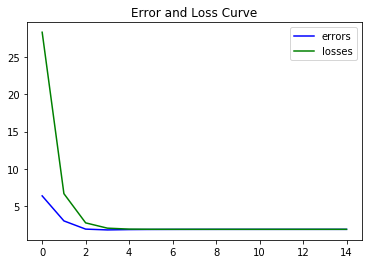

```
-------------------------------------------- Test Results --------------------------------------------

The average test error is : [11.10900937].

The average test loss is : [66.87310085].
```

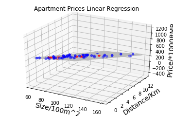

```python
# first train, lr = 0.00015, GD
myLR1 = LinearRegression(0.00015, 0., 0., 0., 1500000, 100000)
myLR1.train_GD()
myLR1.test()
show_regression(train_sizes, train_distances, train_prices, test_sizes, test_distances, test_prices, myLR1.w1, myLR1.w2, myLR1.bias)
```

## Exercise 2

Now, you change the learning rate to a number of different values, for instance, to 0.0002 (you may also change the number of iterations as well) and then train the model again. What can you find? Please conclude your findings.

```
-------------------------------------------- Iteration 0 --------------------------------------------

w_sizes, w_distances, w_bias = [6.98761933], [-72.65171904], [56.69209853] correspondingly.

The average train error is [4.8810339], the average train loss is [16.83223109].

-------------------------------------------- Iteration 1 --------------------------------------------

w_sizes, w_distances, w_bias = [6.83412506], [-72.46751181], [72.18002651] correspondingly.

The average train error is [2.16244761], the average train loss is [3.43470716].

-------------------------------------------- Iteration 2 --------------------------------------------

w_sizes, w_distances, w_bias = [6.78502786], [-72.40859065], [77.13404798] correspondingly.

The average train error is [1.82805352], the average train loss is [2.06397163].

-------------------------------------------- Iteration 3 --------------------------------------------

w_sizes, w_distances, w_bias = [6.76932346], [-72.38974393], [78.71865818] correspondingly.

The average train error is [1.88047821], the average train loss is [1.92372811].

-------------------------------------------- Iteration 4 --------------------------------------------

w_sizes, w_distances, w_bias = [6.7643002], [-72.38371555], [79.22551701] correspondingly.

The average train error is [1.89724695], the average train loss is [1.90937943].

-------------------------------------------- Iteration 5 --------------------------------------------

w_sizes, w_distances, w_bias = [6.76269344], [-72.3817873], [79.3876426] correspondingly.

The average train error is [1.90261066], the average train loss is [1.90791138].

-------------------------------------------- Iteration 6 --------------------------------------------

w_sizes, w_distances, w_bias = [6.76217949], [-72.38117052], [79.43950064] correspondingly.

```

[output cut: 36 more lines]

```
The average train error is [1.90513231], the average train loss is [1.90774406].

-------------------------------------------- Iteration 13 --------------------------------------------

w_sizes, w_distances, w_bias = [6.76193787], [-72.38088055], [79.46388076] correspondingly.

The average train error is [1.9051329], the average train loss is [1.90774406].

-------------------------------------------- Iteration 14 --------------------------------------------

w_sizes, w_distances, w_bias = [6.76193782], [-72.38088048], [79.46388644] correspondingly.

The average train error is [1.90513308], the average train loss is [1.90774406].

-------------------------------------------- Training Curve --------------------------------------------
```

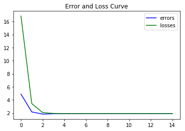

```
-------------------------------------------- Test Results --------------------------------------------

The average test error is : [11.1090291].

The average test loss is : [66.87324595].
```

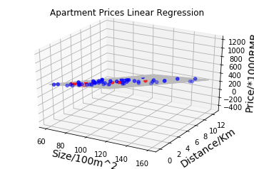

```python
# second train, lr = 0.0002, GD
myLR2 = LinearRegression(0.0002, 0., 0., 0., 1500000, 100000)
myLR2.train_GD()
myLR2.test()
show_regression(train_sizes, train_distances, train_prices, test_sizes, test_distances, test_prices, myLR2.w1, myLR2.w2, myLR2.bias)
```

## Exercise 3

Now, we turn to use other optimization methods to get the optimal parameters. Can you use **Stochastic Gradient Descent** to get the optimal parameters? Plots the training error and the testing error at each K-step iterations (the size of K is set by yourself). Can you analyze the plots and make comparisons to those findings in Exercise 1?

```
-------------------------------------------- Iteration 0 --------------------------------------------

w_sizes, w_distances, w_bias = [6.98570229], [-72.65869529], [56.99593167] correspondingly.

The average train error is [4.88101026], the average train loss is [16.86762276].

-------------------------------------------- Iteration 1 --------------------------------------------

w_sizes, w_distances, w_bias = [6.83259187], [-72.46998117], [72.37490051] correspondingly.

The average train error is [2.16644415], the average train loss is [3.4415893].

-------------------------------------------- Iteration 2 --------------------------------------------

w_sizes, w_distances, w_bias = [6.78430648], [-72.41046768], [77.22486115] correspondingly.

The average train error is [1.85611188], the average train loss is [2.10832439].

-------------------------------------------- Iteration 3 --------------------------------------------

w_sizes, w_distances, w_bias = [6.76907905], [-72.39169932], [78.7543602] correspondingly.

The average train error is [1.90778812], the average train loss is [1.97635888].

-------------------------------------------- Iteration 4 --------------------------------------------

w_sizes, w_distances, w_bias = [6.76427688], [-72.38578047], [79.23670789] correspondingly.

The average train error is [1.9240849], the average train loss is [1.963434].

-------------------------------------------- Iteration 5 --------------------------------------------

w_sizes, w_distances, w_bias = [6.76276245], [-72.38391388], [79.3888226] correspondingly.

The average train error is [1.92922431], the average train loss is [1.96221152].

-------------------------------------------- Iteration 6 --------------------------------------------

w_sizes, w_distances, w_bias = [6.76228485], [-72.38332523], [79.43679398] correspondingly.

```

[output cut: 36 more lines]

```
The average train error is [1.93159093], the average train loss is [1.96210869].

-------------------------------------------- Iteration 13 --------------------------------------------

w_sizes, w_distances, w_bias = [6.76206493], [-72.38305416], [79.45888411] correspondingly.

The average train error is [1.93159143], the average train loss is [1.9621087].

-------------------------------------------- Iteration 14 --------------------------------------------

w_sizes, w_distances, w_bias = [6.76206488], [-72.3830541], [79.4588888] correspondingly.

The average train error is [1.93159159], the average train loss is [1.96210871].

-------------------------------------------- Training Curve --------------------------------------------
```

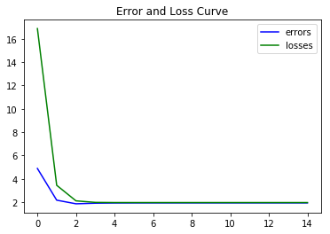

```
-------------------------------------------- Test Results --------------------------------------------

The average test error is : [11.10925859].

The average test loss is : [66.88540843].
```

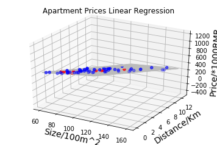

```python
# third train, lr = 0.0002, SGD
myLR3 = LinearRegression(0.0002, 0., 0., 0., 30000, 2000)
myLR3.train_SGD()
myLR3.test()
show_regression(train_sizes, train_distances, train_prices, test_sizes, test_distances, test_prices, myLR3.w1, myLR3.w2, myLR3.bias)
```

As for SGD, we update weights 50 times each iteration, so we only need 1500000/50 = 30000 epochs to train. This model has almost the same accuracy compared with the former two. But apparently, this model needs a shorter computation time.